# Spain Wave 2: Attitudes towards COVID-19 tracking technologies

Yasmina Okan & Stephan Lewandowsky, preliminary analysis by Paul M. Garrett

21/8/2020

The following provides a snapshot of the results from the second wave of data collected in Spain for the project ‘establishing the social licence for tracking technologies’. Data was collected from August 8th - August 12th 2020.

# Background

The COVID-19 pandemic caused by the severe acute respiratory coronavirus 2 (SARS-CoV-2) disease has changed how people live, work and socialise. In the absence of a vaccine or treatment, behavioral measures such as restricting public gatherings and physical distancing, masking wearing, lockdown policies and hand-washing have been employed to arrest the spread of the virus. Spain has been severely affected by COVID-19; the virus spread rapidly and claimed many lives early in the pandemic, and now as restrictions have eased, Spain is experiencing a second-wave of infections (see Figure 1). The highly transmittable and often asymptomatic nature of this virus (appx 15% of all cases) has required new technological solutions to curve its spread. Smartphone tracking technologies and immunity passports offer two such solutions.

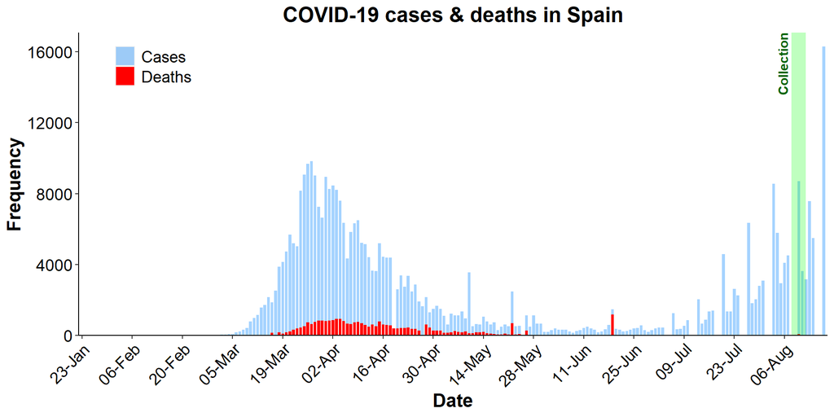

In this study, we asked a sample of the Spanish public about their perceptions of the COVID-19 pandemic, their perceptions about their Government (and other Governments) responses to the pandemic, their attitudes towards and uptake of the newly released ‘COVID Radar’ app, and their attitudes towards the introduction of an immunity passport. The questions and results are as follows.

## Participants

Of 618 participants, 18 (3%) reported that they had tested positive with COVID-19, and 285 (46%) indicated that they knew someone who had tested positive with COVID-19. 23% of participants had lost their job due to COVID-19.

Table 1. Participant selection procedure for data collection.

| Initial Sample | Under 18 | Failed Attention Check | Incomplete | Final Sample |
| --- | --- | --- | --- | --- |
| 1086 | 53 | 415 | 0 | 618 |

| Gender identification: Percentages | Gender identification: Percentages Percent |
| --- | --- |
| Gender |  |
| Men | 48.9 |
| Women | 51.1 |
| Other |  |
| Prefer not to say |  |
| #Total cases | 618 |

| Level of education: Percentages | Level of education: Percentages Percent |
| --- | --- |
| Education |  |
| Basic studies | 11.2 |
| Bachelor/COU | 21.2 |
| FP | 23.0 |
| University degree | 44.7 |
| #Total cases | 618 |

| Income: Percentages | Income: Percentages Percent |
| --- | --- |
| Data$Wealth |  |
| Prefer not to answer | 1.3 |
| Less than 5,000 € | 31.6 |
| Between 5,000 and 24,999 € | 44.8 |
| Between 25,000 and 49,999 € | 7.3 |
| Between 50,000 and 74,999 € | 2 |
| Between 75,000 € and 99,999 € | 5.7 |
| 100,000 € or more | 7.3 |
| #Total cases | 614 |

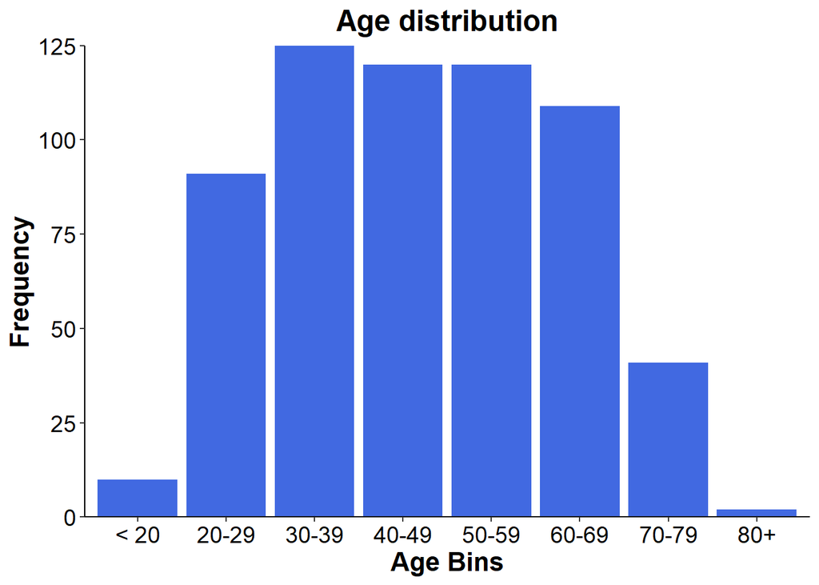

Figure 2. Age bins over the Spanish sample.

# Results

## COVID-19 Infomation Sources

Participants were asked from what sources they receive their information about COVID-19, and how much they trust these sources. Responses were made on a 5 point likert scale. The questions read:

1. How often do you consult the following sources for information on the COVID-19 pandemic?
2. How confident are you in the following sources for correct information about the COVID-19 pandemic?

Figure 3.a displays the likert-style response distributions classifying which informaton source participants received COVID-19 information from (light blue), and the level of trust they have in these sources (dark blue). Figure 3.b displays the mean posterior distribution from a bayesian ordinal regression conducted separately for each item. Error bars are 95% highest density intervals and significant differences within the measures of information source or level of trust can be determed by where the error bars do not overlap.

Results show that participants recieved most of their COVID-19 information from TV and frends/family, then news media and government announcements, followed by social networks, and finally radio and other sources.

Partcipants trusted Friends and Family and News media the most, followed by TV and radio, and finally Goverment announcements and social networks.

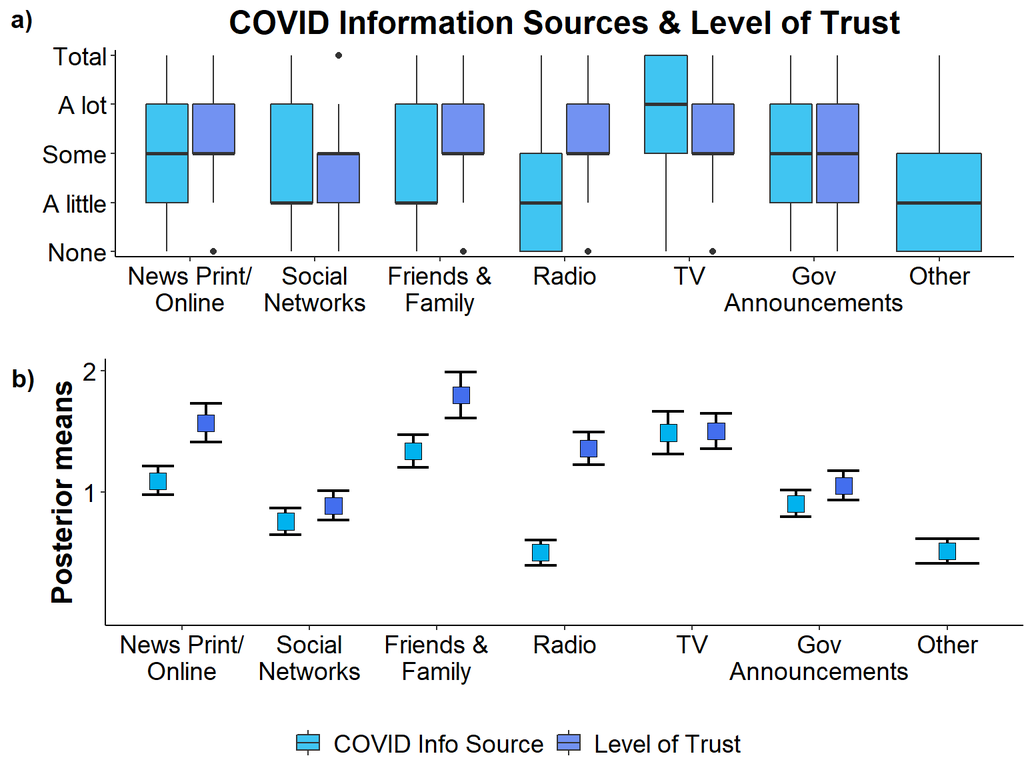

Figure 3. a) Likert-style responses classifying which informaton source participants received COVID-19 information from, and the level of trust they have in these sources. b) Bayesian ordinal regression posterior distributions; error bars are 95% highest density intervals. Significant differences within measures of source or trust can be determined where error bars do not overlap.

## Perceived risk from COVID-19

Particiants were then asked:

1. How severe do you think novel coronavirus (COVID-19) will be for the general population? [General harm]
2. How harmful would it be for your health if you were to become infected COVID-19? [Personal harm]
3. How concerned are you that you might become infected with COVID-19? [Concernn self]
4. How concerned are you that somebody you know might become infected with COVID-19? [Concern others]

Participants viewed COVID-19 as ‘very’ severe for the general population, and as ‘somewhat’ to ‘very’ severed for themselves (Figure 4). They reported being ‘somewhat’ to ‘very’ concerned at becoming infected with COVID-19, or others becoming infected with COVID-19.

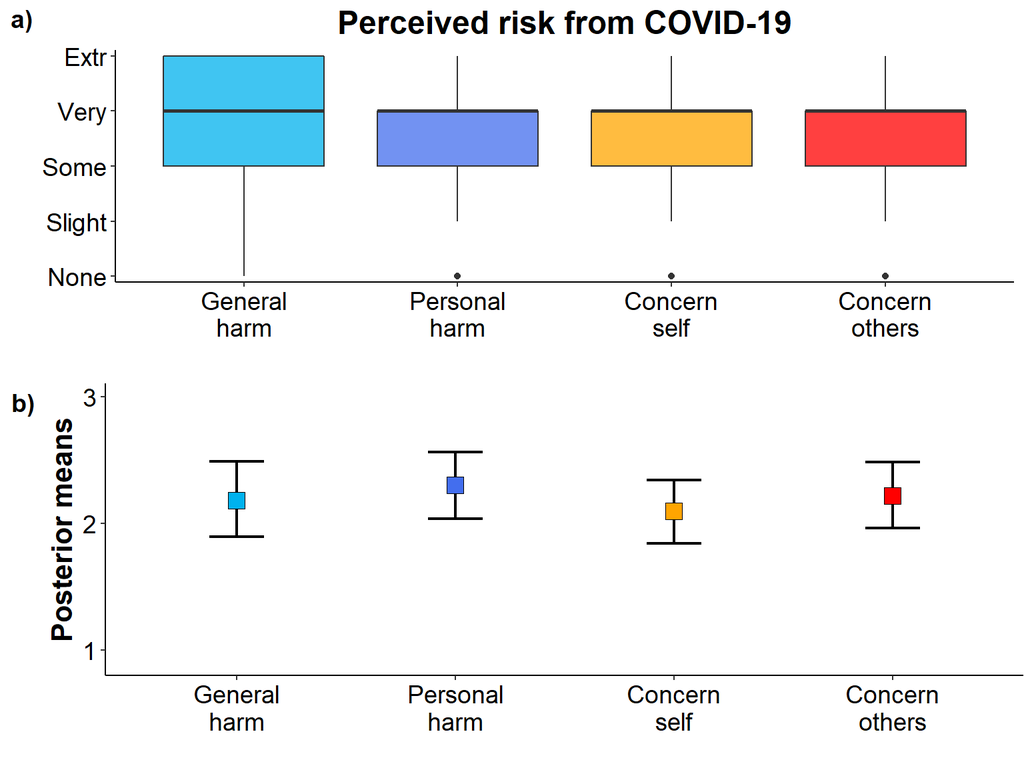

Figure 4. COVID-19 Severity for the general population and one’s self. a) Likert-style responses, and b) Bayesian ordinal regression posterior distributions; error bars are 95% highest density intervals.

We asked participants to report their estimates on the number of fatalities across a range of countries with moderate-to-high media coverage in Spain. Responses were made on a sliding scale ranging from 0 - 200,000; results are reported in estimated deaths per 1000 (Figure 5).

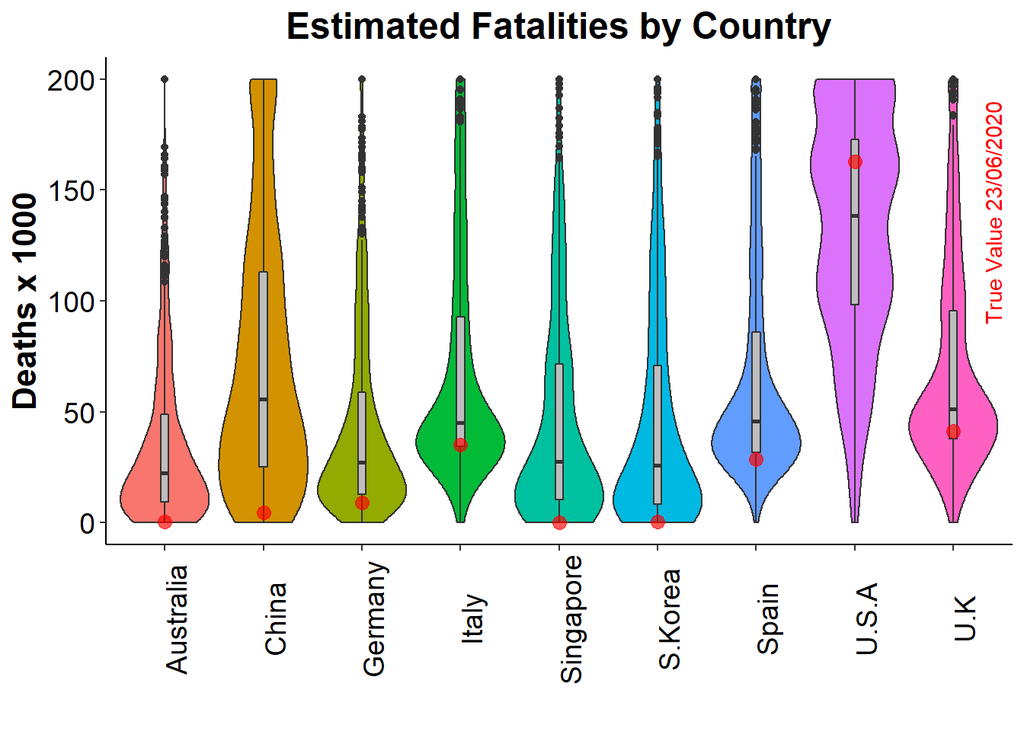

Figure 5. COVID fatality estimates for a range of countries.

## Assessments of the Government’s response to COVID-19

Participants were then asked to determine how helpful Government guidelines have been during the COVID-19 pandemic. The questions were:

1. How well do you feel you understand the government guidelines on measures to combat the COVID-19 pandemic?
2. How useful are government guidelines in deciding how to act in relation to the COVID-19 pandemic?

Results are shown in Figure 6.

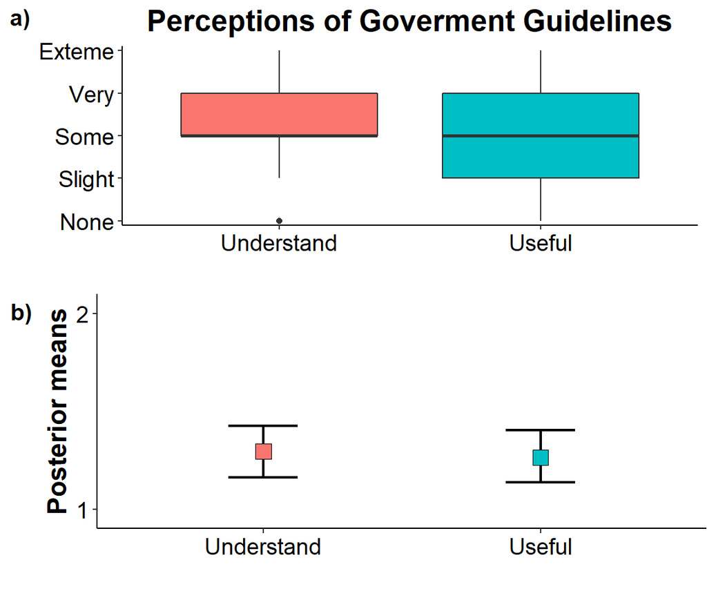

Figure 6. Assessments of Government guidelines. a) Likert-style responses, and b) Bayesian ordinal regression posterior distributions; error bars are 95% highest density intervals.

Participants were asked “Overall, how well do you think the governments of the following countries have managed the COVID-19 pandemic so far?” Responses were made on 5 point likert-scale ranging from ‘not good’ to ‘extremely good’.

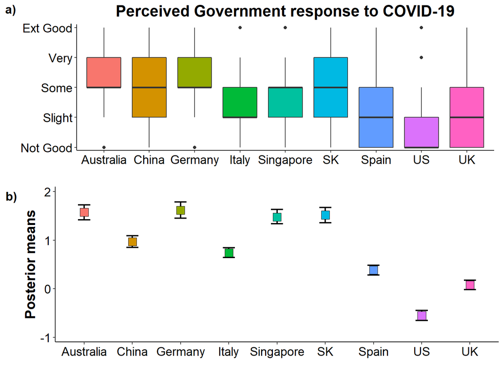

Figure 7. Perceived government’s response to the COVID-19 pandemic in a range of countries.

# Perceptions of COVID-19 Tracking Technologies

Participants were presented with a scenario description of the newly released ‘COVID Radar’ app for tracking the spread of COVID-19 in Spain. The scenario read as:

“The COVID-19 pandemic has quickly become a global threat. Containing the spread of the virus is essential to minimize the impact on the health system and the economy, and to save many lives. The Spanish government has proposed the use of a contact tracing application for current smartphones, to help inform people if they have been exposed to others with COVID-19. The app uses technology from Apple and Google, and could help reduce the spread of COVID-19 in the community by allowing people to voluntarily isolate themselves. When two people are close to each other, their phones would connect via Bluetooth and exchange randomly generated codes. If a person is later known to be infected, people who have been close to them then receive a notification, without the government knowing who they are. The random codes would be stored on the users’ phone and would be removed after 14 days. Also, the random identifiers that have been sent to the application server by users diagnosed with COVID-19 would be removed after 14 days. Both the use of the application and the communication of a possible contagion would be completely voluntary. The people who receive the notification would not be informed who has tested positive. No user can be identified or located, because the application does not request, use or store personal data. In no case are the movements of the users tracked, and therefore geolocation would not be possible. The application is currently available to the autonomous communities that wish to request it.”

Immediately following this scearnio, participants were asked a scenario comprehension (attention) check, followed by items probing their attitudes towards the risks and benefits of using of the proposed app. Finally, participants were asked if they were aware of and were currently using the Radar COVID app. For plotting purposes, the benefits and risks of the proposed app will be presented separately, and the first and final two questions will be presented together showing app acceptance, app awareness and app downloads.

Figure 8 displays responses to the following items assessing the beneifts of the proposed tracking technology:

1. In this scenario, how confident are you that the contact tracing app would reduce the likelihood of you getting COVID-19? [Reduce contraction]
2. In this scenario, how confident are you that the contact tracing application would help you resume normal activities more quickly? [Reduce spread]
3. In this scenario, how confident are you that the contact tracing app would reduce the spread of COVID-19 in your community? [Resume activities]

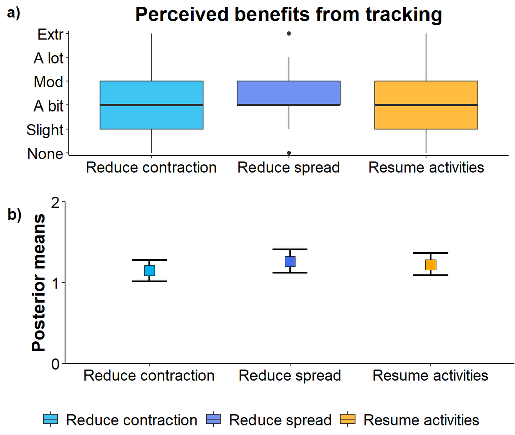

Figure 8. Perceived benefits of tracking technologies. a) Likert-style responses, and b) Bayesian ordinal regression posterior distributions; error bars are 95% highest density intervals.

Figure 9 displays responses to the following items assessing the perceived risks and harms of downloading the proposed tracking technology.

1. In this scenario, how confident are you that you and others like you would be able to use the contact tracing application effectively?
2. In this scenario, how easy is it for people to refuse to participate in the contact tracing system?
3. In this scenario, to what degree would only the data necessary to meet the contact tracing objectives be collected?
4. In this scenario, how sensitive is the data collected by the contact tracing application?
5. In this scenario, how serious is the risk of harm that may arise from the contact tracing application?
6. In this scenario, how confident are you that the government uses the tracking data only to deal with the COVID-19 pandemic?
7. In this scenario, how confident are you that the government uses the tracking data only to deal with the COVID-19 pandemic?
8. In this scenario, how secure is the data collected by the contact tracing application?
9. In this scenario, to what extent do people have permanent control of their data?

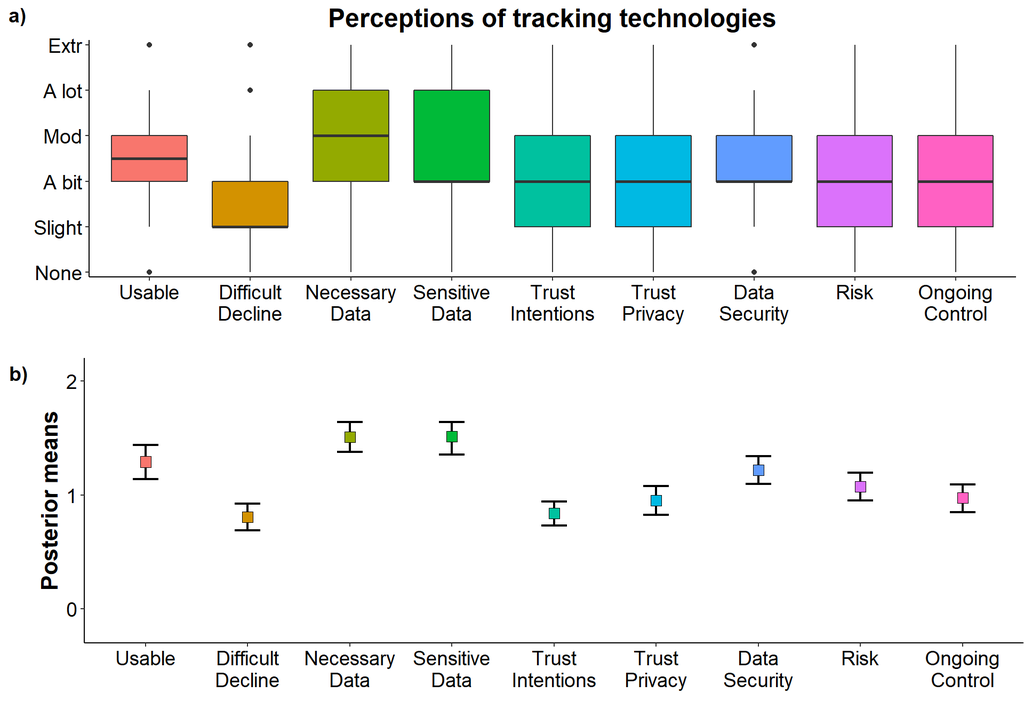

Figure 9. Perceived risks of tracking technologies. a) Likert-style responses, and b) Bayesian ordinal regression posterior distributions; error bars are 95% highest density intervals.

Figure 10 displays responses to the following items:

1. If the COVID-19 contact tracing application for smartphones described in this scenario were available in your autonomous community, would you download it and use it?
2. Have you heard about the COVID Radar app before starting this study?
3. Had you downloaded the Radar COVID application on your smartphone before starting this study?

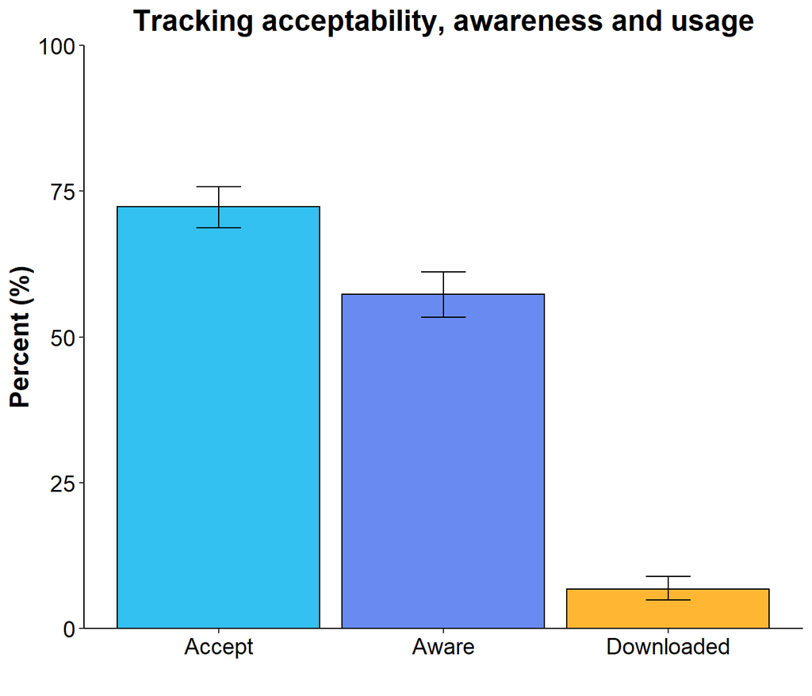

Figure 10. Acceptance, awareness, and usage of a Bluetooth tracking app. Error bars are 95% credible intervals.

## Immunity Passports

Participants were asked their views on “immunity passports” which were explained as follows:

“An ‘immunity passport’ indicates that you have had a disease and that you have antibodies to the virus that causes the disease. Having the antibodies means that you are now immune and therefore cannot spread the virus to other people. Therefore, if an antibody test indicates that you have had the disease, you could be given an ‘immunity passport’ that would later allow you to move freely. Immunity passports have been proposed as a potential step to lift movement restrictions during the COVID-19 pandemic.”

Participants then responded to the following items:

1. What support would you give to a government proposal to introduce ‘immunity passports’ for the new coronavirus (COVID-19)?
2. To what extent are you concerned about the idea of introducing an ‘immunity passport’ for the new coronavirus (COVID-19)?
3. To what extent would you like to receive an ‘immunity passport’ for the new coronavirus (COVID-19), regardless of whether you have actually had COVID-19 or not?
4. To what extent do you think that an ‘immunity passport’ for the new coronavirus (COVID-19) could damage the social fabric of your country?
5. To what extent do you think it is fair that people with ‘immunity passports’ for the new coronavirus (COVID-19) can return to work, while people without this ‘immunity passport’ cannot?

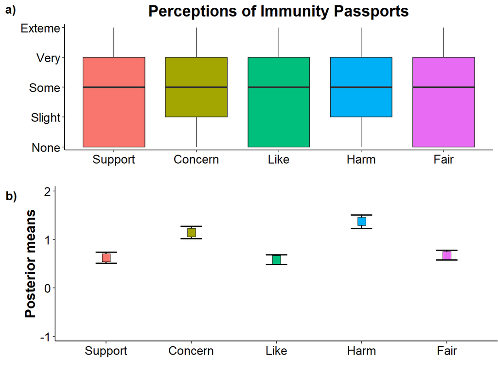

Figure 11. Perceptions of immunity passports. a) Likert-style responses, and b) Bayesian ordinal regression posterior distributions; error bars are 95% highest density intervals.

The following table summarizes results for how much people supported the introduction of Immunity Passports: 27% of participants did not support immunity passports at all, and 19% showed a lot or full support.

|  | #Total |
| --- | --- |
| Final support for Immunity Passports |  |
| Not at all | 26.8 |
| Slightly | 14.8 |
| A bit | 19.2 |
| Moderately | 19.7 |
| A lot | 11.3 |
| Fully | 8.2 |
| #Total cases | 609 |

Finally, participants were asked about their world views with three items assessing their libertarian attitudes. The following presents a composite measure of these world view items against a composite score of their perceived risk of COVID-19. World view items were:

1. An economic system based on the free market, without government interference, works best to meet the needs of citizens
2. The free market system may be efficient in locating resources, but it is limited in its ability to promote social justice.
3. The government should interfere as little as possible in the lives of citizens.

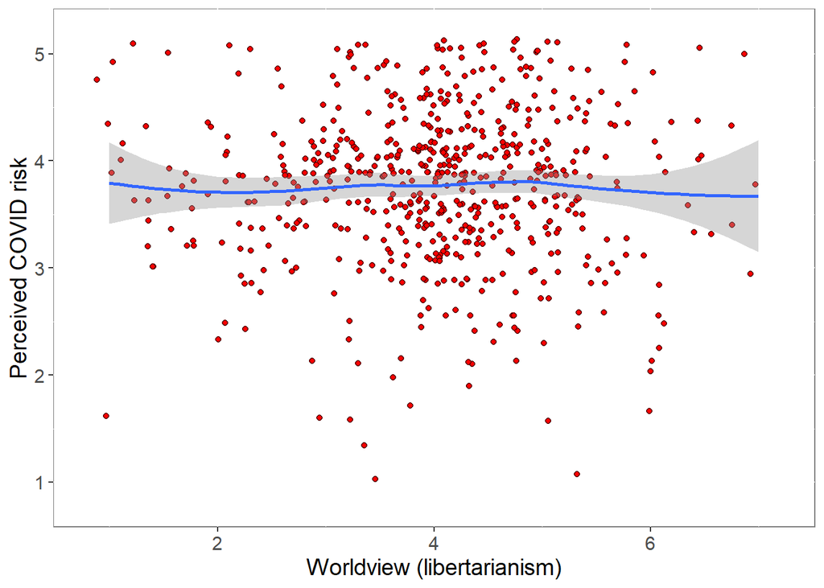

Figure 12. Worldview items vs. participant perceived risk from COVID-19.

```
##
##  Pearson's product-moment correlation
##
## data:  Data$WorldView and Data$COVIDrisk
## t = 0.16104, df = 607, p-value = 0.8721
## alternative hypothesis: true correlation is not equal to 0
## 95 percent confidence interval:
##  -0.07295172  0.08594210
## sample estimates:
##         cor
## 0.006536448
```